# Progress Memo 2

Final Project  
Data Science 1 with R (STAT 301-1)

Author

Caroline Corr

Published

December 2, 2024

# Overview

[GitHub Link](https://github.com/stat301-1-2024-fall/final-project-1-carolinecorr)

It has long been said that Survivor as an institution reflects the cultural climate of our society. As a reality show made up of everyday people, it naturally follows that the biases that impact our society would also spill over into the game. Survivor is an intensely social game: it requires you to make your competitors like you and respect your gameplay enough that they will vote for you to win after all of the deceit and “strategery” it took to get yourself to the final 3.

Since your fate in the game ultimately depends on the feelings and opinions of one’s fellow competitors, I am interested in assessing how demographic information is related to the results of the game and the state of the competition over time. For the first part of my analysis, I am seeking to uncover any potential relationships between age, gender, race, and sexuality and how they impact the individual contestant’s performance on the show. Later, I will assess these relationships on the tribe level by looking at the demographic compositions of pre-merge tribes and how tribe performance differs according to said makeup.

# Assessing Bias in Survivor

### Contestant age and final placement:

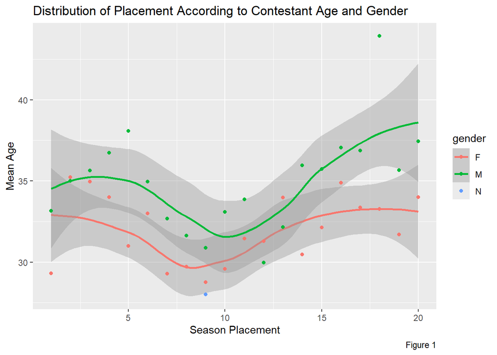

Table 1

| finish | gender | mean_age | median_age |
| --- | --- | --- | --- |
| 1 | F | 29.29412 | 29.0 |
| 1 | M | 33.15385 | 33.5 |
| 2 | F | 35.23077 | 33.0 |
| 2 | M | 35.00000 | 33.0 |
| 3 | F | 34.94444 | 29.0 |
| 3 | M | 35.63158 | 33.0 |
| 4 | F | 34.00000 | 32.0 |
| 4 | M | 36.72222 | 31.5 |
| 5 | F | 31.00000 | 28.0 |
| 5 | M | 38.08333 | 35.0 |
| 6 | F | 33.00000 | 30.0 |
| 6 | M | 34.95000 | 31.0 |
| 7 | F | 29.29167 | 28.5 |
| 7 | M | 32.68421 | 30.0 |
| 8 | F | 29.72222 | 27.0 |
| 8 | M | 31.64000 | 30.0 |
| 9 | F | 28.75000 | 26.0 |
| 9 | M | 30.86667 | 28.0 |
| 9 | N | 28.00000 | 28.0 |
| 10 | F | 29.58824 | 28.0 |
| 10 | M | 33.07692 | 29.0 |
| 11 | F | 31.45455 | 28.5 |
| 11 | M | 33.85714 | 32.0 |
| 12 | F | 31.29412 | 29.0 |
| 12 | M | 29.96154 | 28.5 |
| 13 | F | 33.96667 | 31.0 |
| 13 | M | 32.15385 | 32.0 |
| 14 | F | 30.47368 | 27.0 |
| 14 | M | 35.95833 | 34.0 |
| 15 | F | 32.12000 | 27.0 |
| 15 | M | 35.72222 | 31.5 |
| 16 | F | 34.88462 | 33.5 |
| 16 | M | 37.05882 | 35.0 |
| 17 | F | 33.35294 | 28.0 |
| 17 | M | 36.87500 | 33.0 |
| 18 | F | 33.27778 | 30.0 |
| 18 | M | 43.93333 | 45.0 |
| 19 | F | 31.70000 | 29.0 |
| 19 | M | 35.66667 | 33.0 |
| 20 | F | 34.00000 | 33.5 |
| 20 | M | 37.42857 | 35.0 |

I decided to assess the relationship between contestant age and placement with the added layer of gender because I believe this could be a major source of bias both on the casting level and on the competition level. Figure 1 reveals that in general, male contestants tend to be older than female ones. Interestingly, both genders follow similarly shaped distributions. Both are roughly bimodal with peaks around 4th place and 15-20th place finishes.

I believe the difference between mean age for men and women could be a result of bias on the casting/production level. It appears that older men are more likely to appear on Survivor than older women. This could be explained by a number of things, but I am inclined to believe that parenthood could be a major contributing factor. In general, mothers may feel less inclined to apply to be on Survivor than fathers, or perhaps older women feel less empowered to apply because of societal norms about aging women that they have internalized.

Another interesting facet of this visual is the dip in both distributions around the 10-12th place range. “The Merge” is the point in the season where competing tribes drop their buffs and combine into one large tribe with all of the remaining contestants, and this usually occurs when there are 10-12 competitors left. Figure 1 appears to suggest that older contestants are either more likely to be early outs or place within the final episodes. As a long time fan of the show, I believe this could be because exceptionally fit older competitors often become coveted allies amongst their tribemates, as they are seen as more loyal and are able to perform at a higher level without increasing their threat level as much as a younger physical threat might.

### Average contestant age over time:

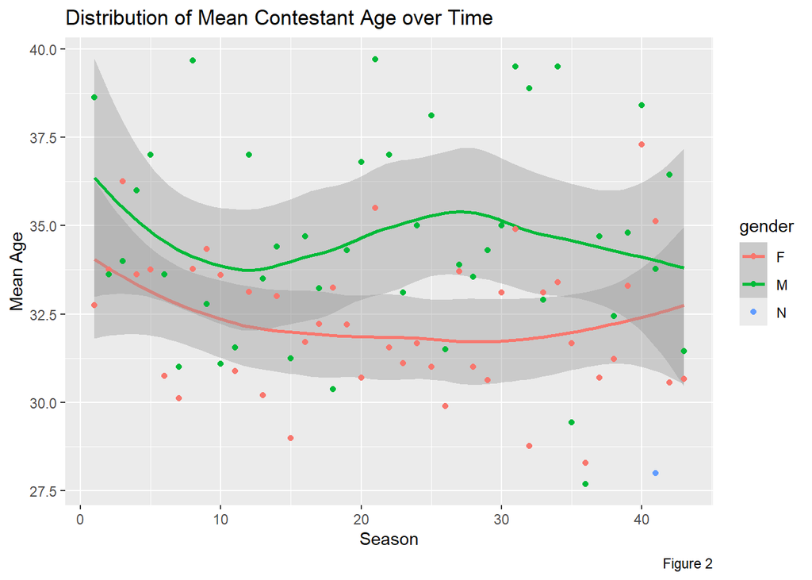

Table 2

| num_season | gender | mean_age | median_age |
| --- | --- | --- | --- |
| 1 | F | 32.75000 | 28.0 |
| 1 | M | 38.62500 | 30.0 |
| 2 | F | 33.75000 | 31.0 |
| 2 | M | 33.62500 | 33.0 |
| 3 | F | 36.25000 | 35.5 |
| 3 | M | 34.00000 | 32.5 |
| 4 | F | 33.62500 | 32.0 |
| 4 | M | 36.00000 | 34.5 |
| 5 | F | 33.75000 | 28.5 |
| 5 | M | 37.00000 | 35.5 |
| 6 | F | 30.75000 | 27.5 |
| 6 | M | 33.62500 | 29.5 |
| 7 | F | 30.12500 | 25.5 |
| 7 | M | 31.00000 | 30.0 |
| 8 | F | 33.77778 | 33.0 |
| 8 | M | 39.66667 | 40.0 |
| 9 | F | 34.33333 | 31.0 |
| 9 | M | 32.77778 | 33.0 |
| 10 | F | 33.60000 | 30.5 |
| 10 | M | 31.10000 | 27.0 |
| 11 | F | 30.88889 | 30.0 |
| 11 | M | 31.55556 | 24.0 |
| 12 | F | 33.12500 | 31.5 |
| 12 | M | 37.00000 | 33.5 |
| 13 | F | 30.20000 | 30.0 |
| 13 | M | 33.50000 | 30.5 |
| 14 | F | 33.00000 | 27.0 |
| 14 | M | 34.40000 | 30.0 |
| 15 | F | 29.00000 | 27.0 |
| 15 | M | 31.25000 | 31.0 |

[output cut: 57 more lines]

Survivor has been on the air for almost 25 years, so it is entirely possible that social conventions surrounding age and ability have had varying influences on the game over time. Figure 2 demonstrates how mean contestant age has changed over the seasons with gender as an added point of consideration. It appears that male contestants have witnessed more fluctuations in mean age over the years whereas female contestants have been getting gradually younger up until very recently.

The pattern of male contestants being older than female contestants has held constant over the years, but it seems that the gap is becoming smaller as we near the modern era of Survivor. Notably, there was a major rule change beginning in season 41 where the duration of the competition changed from 39 days to 26 days. Perhaps this could hold some explanatory power as to why female contestants are getting older and male contestants are getting younger.

# PM2: Next Steps

I am currently still looking at how demographic information can influence outcomes across seasons in Survivor. At this point, I have done a lot of work concerning contestant age, but I will turn to race and sexuality next while still holding gender as a consideration in these analyses. I am also interested in finding a way to look at how profession impacts placement, for it is a long-held custom that financial need is a major consideration for jurors.

After assessing these contestant-level biases, I also want to look at how the demographic compositions of tribes influence the game. There are some seasons where one tribe consistently gets sent to tribal council while the others enjoy rewards, fire, and higher numbers until the merge, and I think demographic information could play a role in these patterns.